# Project 1, Phase 2

Emilia Pompe, Małgorzata Pujszo

Wednesday, November 11, 2015

### Main idea

Our approach was to find a list of genes that may be used to differentiate all types of genes from each other. In our report also interactions with sex were taken into consideration.

### Table of contents

- Changing the data
- Assumptions and two-way ANOVA
- Models without interactions
- Models with interactions
- Final conclusions

### Changing the data

We have loaded required libraries.

Merging datasets looks similarly as in Phase 1 of the Project 1 but now we don’t delete any outliers.

As before we removed the cancer with only 12 observations.

### Assumptions and two-way ANOVA

We would like to check whether interactions of gender and type of cancer influence genes’ expressions. In order to do this we would like to perform two-way ANOVA. However, we need to check normality of residuals and homogeneity of variances in gropus. We have decided to do these test simultanously in one loop.

We are checking normality of residuals using Shapiro test (p-values for each gene are remembered in shapiro_coeeff1). For homogeneity of variances we are performing Levene test (p-values are stored in levene1). M.anova is a matrix containing p-values of two-way ANOVA and gene’s number.

```r
N <- 16115
shapiro_coeff1 <- rep(NA, times=N)
levene1 <- rep(NA, times=N)
M.anova <- matrix(NA, nrow=N, ncol=4)
M.anova[,4] <- 1:N
```

For each gene we are checking if each group contains more than treshold (in this case 20) observations. If it doesn’t we are removing those groups in order not to infer from such little information. Here is a function which does it.

```r
threshold <- 20
filtered.dataset <- function(i) {
  y <- dataset[,i]
  d <- data.frame(y=y[!(is.na(y))], x=dataset$X_cohort[!(is.na(y))],
                  sex = dataset$gender[!(is.na(y))])
  d <- subset(d, sex %in% c("FEMALE", "MALE"))
  d$sex <- factor(d$sex)
  tab <- as.data.frame(table(d$x, d$sex))
  bad.female <-intersect(which(tab[,3]<=threshold), which(tab[,2]=="FEMALE"))
  bad.male <-intersect(which(tab[,3]<=threshold), which(tab[,2]=="MALE"))
  d <- filter(d, !(x %in% tab[bad.female, 1] & sex=="FEMALE"))
  d <- filter(d, !(x %in% tab[bad.male, 1] & sex=="MALE"))
  d$x <- factor(d$x)
  d$sex <- factor(d$sex)
  d
  }
```

Here is the loop performing our tests.

```r
for(i in 2:(N+1)){
  d <- filtered.dataset(i)
  model <- lm(y~ x * sex, data=d)
  shapiro_coeff1[i-1] <- shapiro.test(rstandard(model))$p.value
  levene1[i-1] <- leveneTest(d$y~d$x*d$sex)[1,3]
  M.anova[i-1,1:3] <- anova(model)[1:3,5]
}
```

Now, we would like to find reasonable threshold for Shapiro test’s p-value. We created a data frame with sorted p-values.

```r
shapiro.data <- data.frame(nr=1:N, shapiro = shapiro_coeff1)
shapiro.data.new <- arrange(shapiro.data, shapiro)
```

Let’s see what is happening with gene with the lowest p-value.

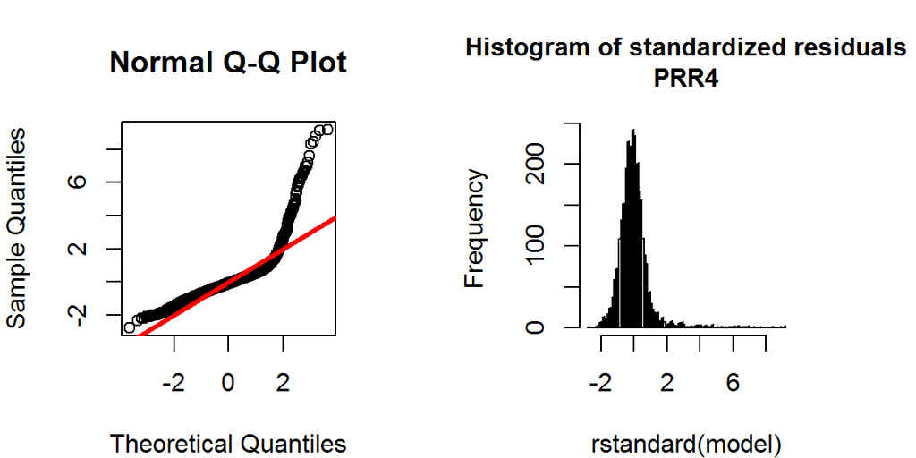

```r
par(mfrow=c(1, 2), mar=c(4, 4, 4, 4))
d <- filtered.dataset(shapiro.data.new$nr[1]+1)
model <- lm(y ~ x * sex, data=d)
qqnorm(rstandard(model))
abline(0, 1, col="red", lwd=3)
hist(rstandard(model), breaks=100, main=paste0("Histogram of standardized residuals\n", colnames(dataset)[shapiro.data.new$nr[1]+1]), cex.main=1)
```

As we can see the tail is heavy so we cannot perform ANOVA test in this case. We plotted several more examples, not all of them are shown here. We noticed that gene named GOLT1B with p-value of order 10^(-34) is quite good whereas gene named LSM1 with p-value of order 10^(-35) has heavy right tail.

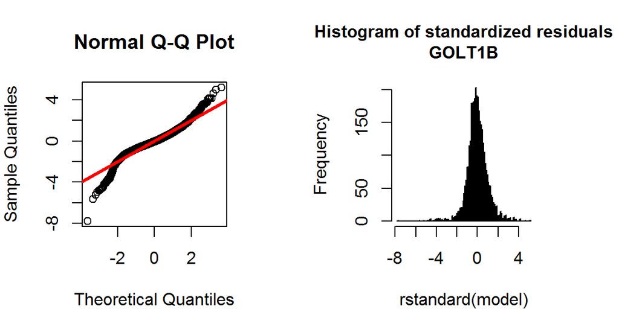

```r
par(mfrow=c(1, 2), mar=c(4, 4, 4, 4))
i <- 5823
d <- filtered.dataset(i)
model <- lm(y~ x * sex, data=d)
qqnorm(rstandard(model))
abline(0, 1, col="red", lwd=3)
hist(rstandard(model), breaks=100, main=paste0("Histogram of standardized residuals\n", colnames(dataset)[i]), cex.main=1)
```

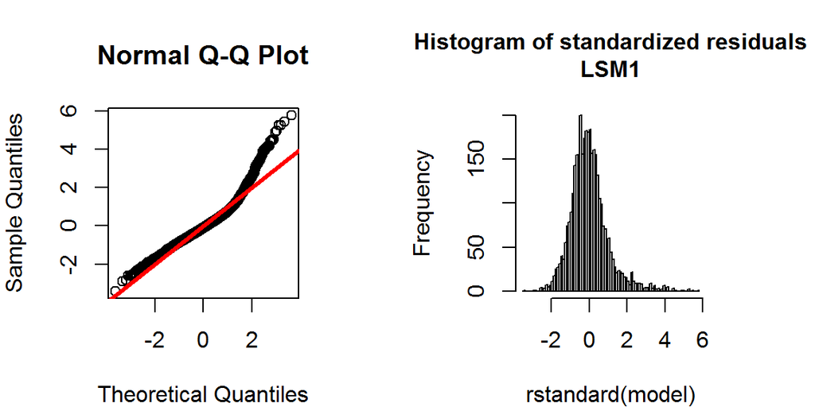

```r
i <- 8149
d <- filtered.dataset(i)
model <- lm(y~ x * sex, data=d)
qqnorm(rstandard(model))
abline(0, 1, col="red", lwd=3)
hist(rstandard(model), breaks=100, main=paste0("Histogram of standardized residuals\n", colnames(dataset)[i]), cex.main=1)
```

We decided to take 10^(-34) as a threshold for p-value for this test. Similarly, we need to find reasonable threshold for Levene test.

```r
levene.data <- data.frame(nr=1:N, levene = levene1)
levene.data.new <- arrange(levene.data, levene)
```

We have chosen significance level equal to 10^(-42). For the first gene with p-value higher than this cutoff, we displayed the highest and the lowest variances in groups.

```r
i <- levene.data.new[min(which(levene.data.new[,2]>= 10^(-42))), 1]+1
d <- filtered.dataset(i)
model <- lm(y~ x * sex, data=d)
d$res <- model$residuals
variances <- ddply(d, .(x, sex), summarize, var = var(res))
min(variances$var)
```

```
## [1] 0.2398677
```

```r
max(variances$var)
```

```
## [1] 2.02036
```

In comparison to this variable, the highest and lowest variances in groups of the variable with the highest p-value are the following.

```r
i <- levene.data.new[which.max(levene.data.new$levene),1]+1
d <- filtered.dataset(i)
model <- lm(y~ x * sex, data=d)
d$res <- model$residuals
variances <- ddply(d, .(x, sex), summarize, var = var(res))
min(variances$var)
```

```
## [1] 0.447059
```

```r
max(variances$var)
```

```
## [1] 0.7809055
```

And the same results for the lowest p-value.

```r
i <- levene.data.new[1,1]+1
d <- filtered.dataset(i)
model <- lm(y~ x * sex, data=d)
d$res <- model$residuals
variances <- ddply(d, .(x, sex), summarize, var = var(res))
min(variances$var)
```

```
## [1] 0.2272213
```

```r
max(variances$var)
```

```
## [1] 7.696921
```

All our significance levels look as follows:

```r
p.value.shapiro.threshold <- 10^(-34)
p.value.levene.threshold <- 10^(-42)
cancer.p.value <- 0.05
interaction.p.value <- 0.05
```

### Models without interactions

Firstly, we chose genes for which the assumptions of two-way ANOVA hold. For them we used p-value adjustment using the Holm method. used.genes is a vector of numbers of genes for which the effect of cancer is significant but the effect of interaction is not significant.

```r
p.value.genes <- intersect(which(shapiro_coeff1 > p.value.shapiro.threshold),
                           which(levene1 > p.value.levene.threshold))
M.anova.part <- M.anova[p.value.genes,]
M.anova.used <- cbind(matrix(p.adjust(as.vector(M.anova.part[,1:3]), method= "holm"), ncol=3), M.anova.part[,4])
M.anova.used <- as.data.frame(M.anova.used)
colnames(M.anova.used) <- c("cancer.pvalues", "sex.pvalues", "interaction.pvalues", "nr")
used.genes <- M.anova.used$nr[intersect(which(M.anova.used[,3]> interaction.p.value), which(M.anova.used[,1]< cancer.p.value))]
```

For each of the chosen genes we created a linear model without interactions with sex. Afterwards, we performed the LSD test - it was chosen as the groups sizes are unbalanced. For each result of the LSD test we checked whether the gene with the highest mean (or with the lowest mean, respectively) is in its own group. We decided to do this, as these genes will have an easy interpretation. Finally, for each type of cancer we found many genes that may be used for detecting it. The most interesting ones are those for which difference of the means for the ‘highest/lowest’ type of cancer and the ‘next one’ is large. Here we used ‘relative difference’ - we divided difference in means by standard deviation of the variable.

```r
results <- data.frame(highest=rep(NA,times=N), lowest=rep(NA,times=N),
                      difference.highest=rep(NA, times=N), difference.lowest=rep(NA, times=N))
for (k in used.genes){
  i <- k+1
  d<-filtered.dataset(i)
  model <- LSD.test(lm(y~ x, data=d), "x")
  groups <- as.character(model$group[,"M"])
  high.mean <- grep("a", groups)
  if(length(high.mean)==1){
    results$highest[k] <- as.character(model$group[,"trt"])[1]
    results$difference.highest[k] <- (model$groups[1, c("means")] - model$groups[2, c("means")])/sd(d$y)
  }
  low.mean <- grep(groups[length(groups)], groups)
  if(length(low.mean)==1){
    results$lowest[k] <- as.character(model$group[,"trt"])[length(groups)]
    results$difference.lowest[k] <- (model$groups[length(groups),c("means")] - model$groups[(length(groups)-1), c("means")])/sd(d$y)
  }
}
```

For each type of cancer we would like to present one gene which differentiates it from other ones. We chose genes with the highest/lowest ‘relative differences’, obtaining a data frame all.means.genes that looks as follows:

```r
highest.means.genes <- data.frame(name=rep(NA,times=nlevels(dataset$X_cohort)),
                                  difference=rep(NA,times=nlevels(dataset$X_cohort)),
                                  nr=rep(NA,times=nlevels(dataset$X_cohort)))
lowest.means.genes <- data.frame(name=rep(NA,times=nlevels(dataset$X_cohort)),
                                 difference=rep(NA,times=nlevels(dataset$X_cohort)),
                                 nr=rep(NA,times=nlevels(dataset$X_cohort)))
i <-1
for (cancer.names in levels(dataset$X_cohort)){
  v <- grep(cancer.names, results$highest)
  cancer.genes <- results[v,c(1,3,5)]
  highest.means.genes[i,] <- cancer.genes[which.max(cancer.genes$difference.highest),]
  v <- grep(cancer.names, results$lowest)
  cancer.genes <- results[v,c(2,4,5)]
  lowest.means.genes[i,] <- cancer.genes[which.min(cancer.genes$difference.lowest),]
  i <- i+1
}
all.means.genes <- cbind(highest.means.genes, lowest.means.genes)[,-4]
all.means.genes$name <- levels(dataset$X_cohort)
all.means.genes
```

```
##                                 name difference    nr difference.1  nr.1
## 1        TCGA Acute Myeloid Leukemia  3.1216976 10422   -4.8020642  1200
## 2                TCGA Bladder Cancer  1.9226885 14939   -1.2250543  2938
## 3                 TCGA Breast Cancer  1.8151265 14349   -1.0271988  4825
## 4                  TCGA Colon Cancer  0.8652204  9586   -1.3612208 15920
## 5           TCGA Endometrioid Cancer  1.3051560  4793   -2.4005626  1694
## 6                  TCGA Glioblastoma  3.0243827  1197   -4.1052408 11889
## 7          TCGA Head and Neck Cancer  1.7074321  3484   -1.0685719  3314
## 8   TCGA Kidney Clear Cell Carcinoma  2.0489664 11535   -1.8209168 11036
## 9           TCGA Lung Adenocarcinoma  2.5927774  7893   -0.8626393  6079
## 10 TCGA Lung Squamous Cell Carcinoma  1.0468473   307   -0.6123970  2348
## 11               TCGA Ovarian Cancer  1.7968288 15469   -2.6207012 11981
## 12                TCGA Rectal Cancer  0.7360448   599   -0.7987748  1295
```

We plotted ‘plot.design’ for each type of cancer (gene names are presented in the plot titles).

```
## [1] "TCGA Acute Myeloid Leukemia"
##
##                                     FEMALE MALE
##   TCGA Acute Myeloid Leukemia           80   93
##   TCGA Bladder Cancer                   34   88
##   TCGA Breast Cancer                   831    9
##   TCGA Colon Cancer                     98   92
##   TCGA Endometrioid Cancer             369    0
##   TCGA Glioblastoma                     58  107
##   TCGA Head and Neck Cancer             81  222
##   TCGA Kidney Clear Cell Carcinoma     167  309
##   TCGA Lung Adenocarcinoma             186  164
##   TCGA Lung Squamous Cell Carcinoma     67  191
##   TCGA Ovarian Cancer                  265    0
##   TCGA Rectal Cancer                    33   39
```

```
## [1] "TCGA Breast Cancer"
##
##                            FEMALE MALE
##   TCGA Breast Cancer           32    0
##   TCGA Colon Cancer            68   69
##   TCGA Endometrioid Cancer    267    0
##   TCGA Glioblastoma            53  104
##   TCGA Ovarian Cancer          76    0
##   TCGA Rectal Cancer           20   21
```

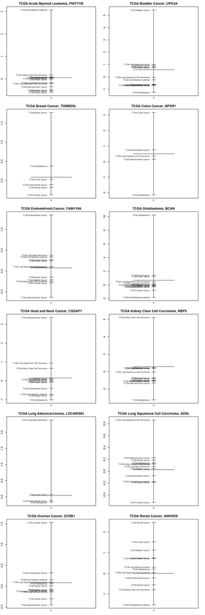

```r
par(mfrow=c(6,2), mar=c(2,2,2,2))
i <-1
for (cancer.names in levels(dataset$X_cohort)) {

  nr.gene <- ifelse(abs(all.means.genes[i,2])>=abs(all.means.genes[i,2]), all.means.genes[i,3], all.means.genes[i,5])
  d <- filtered.dataset(nr.gene+1)
  plot.design(y~x, data=d, main=paste0(cancer.names,", ",
                                       colnames(dataset)[nr.gene+1]), cex=0.7)
  if(cancer.names %in% c("TCGA Breast Cancer", "TCGA Acute Myeloid Leukemia")){
    y <- dataset[,nr.gene+1]
    d <- data.frame(y=y[!(is.na(y))], x=dataset$X_cohort[!(is.na(y))], sex = dataset$gender[!(is.na(y))])
    d <- subset(d, sex %in% c("FEMALE", "MALE"))
    bad <- names(which(table(d$x) < threshold))
    d <- filter(d, !(x %in% bad))
    d$x <- factor(d$x)
    d$sex <- factor(d$sex)
    print(cancer.names)
    print(table(d$x, d$sex))
    }
  i <- i+1
}
```

One thing that needs to be clarified is the fact that our procedure might have deleted some significant levels e.g. all observations belonging to the Bladder Cancer. We presented a ‘good’ and a ‘bad’ example above.

For ‘bads’ we need to find the better examples of genes.

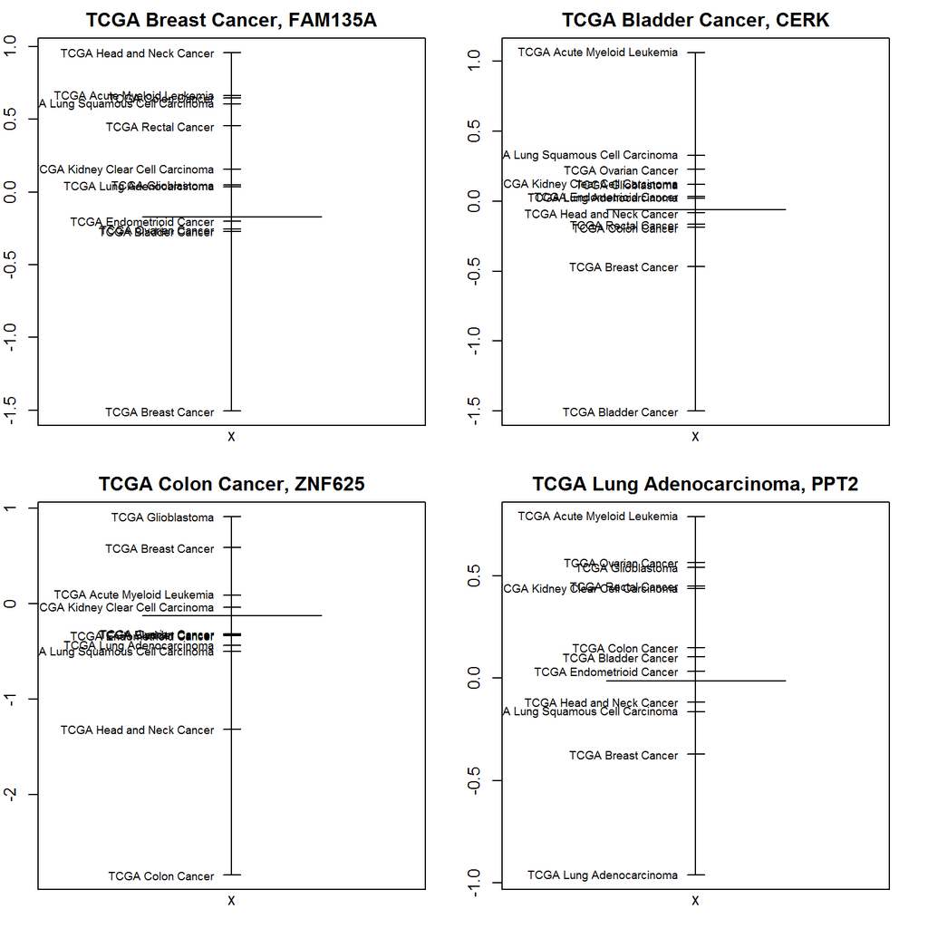

```r
  par(mfrow=c(2,2), mar=c(2,2,2,2))
  cancer.names <- "TCGA Breast Cancer"
  nr.gene <- 4825
  d <- filtered.dataset(nr.gene+1)
  plot.design(y~x, data=d, main=paste0(cancer.names,", ",
                                       colnames(dataset)[nr.gene+1]), cex=0.7)
  cancer.names <- "TCGA Bladder Cancer"
  nr.gene <- 2938
  d <- filtered.dataset(nr.gene+1)
  plot.design(y~x, data=d, main=paste0(cancer.names,", ",
                                       colnames(dataset)[nr.gene+1]), cex=0.7)
  cancer.names <- "TCGA Colon Cancer"
  nr.gene <- 15920
  d <- filtered.dataset(nr.gene+1)
  plot.design(y~x, data=d, main=paste0(cancer.names,", ",
                                       colnames(dataset)[nr.gene+1]), cex=0.7)
  cancer.names <- "TCGA Lung Adenocarcinoma"
  nr.gene <- 10879
  d <- filtered.dataset(nr.gene+1)
  plot.design(y~x, data=d, main=paste0(cancer.names,", ",
                                       colnames(dataset)[nr.gene+1]), cex=0.7)
```

### Models with interactions

We would like to show names of the genes that have interactions with sex.

```r
interaction.genes <- which(M.anova.used[,3]<= interaction.p.value)
colnames(dataset)[interaction.genes+1]
```

```
##  [1] "ABL2"      "ALOX5AP"   "AMOT"      "ANKRD37"   "ATP6AP1L"
##  [6] "BCL2L1"    "C11orf51"  "C12orf4"   "C12orf47"  "C14orf174"
## [11] "C16orf48"  "C18orf19"  "C19orf20"  "C19orf55"  "C20orf134"
## [16] "C20orf196" "C4orf12"   "C5orf25"   "C7orf11"   "CD28"
## [21] "CDC23"     "CDYL2"     "CEBPZ"     "CHMP1B"    "CLCN1"
## [26] "COL5A3"    "COX4NB"    "DNAH9"     "EIF2C3"    "FAM108A1"
## [31] "FGD5"      "GNRHR2"    "HOXD10"    "KIAA0114"  "KRT83"
## [36] "LANCL1"    "LOC399744" "LOX"       "LYVE1"     "MACROD2"
## [41] "MAP1S"     "MCPH1"     "MRPL27"    "MYO1C"     "NBPF7"
## [46] "NDUFB11"   "NRTN"      "ORAI2"     "PCDHGB5"   "PCK2"
## [51] "PDF"       "PELI1"     "PFKFB3"    "PIGH"      "PSMC4"
## [56] "RAGE"      "RNH1"      "RPL35A"    "SCN1B"     "SDCBP"
## [61] "SLC31A1"
```

We decided to present one special case for the gene called C20orf134.

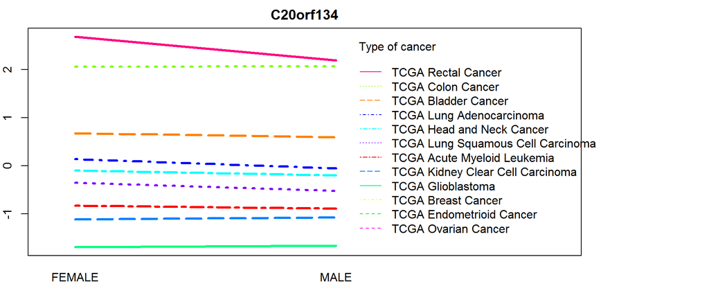

```r
i <- 1891
d <- filtered.dataset(i)
par(mfrow=c(1,1), mar=c(2,2,2,9))
interaction.plot(d$sex, d$x, d$y, col=rainbow(12), lwd=3, main=paste0(colnames(dataset)[1891]), trace.label="Type of cancer")
```

This case is interesting because for the model which doesn’t take sex into consideration we obtained that Rectal Cancer is in its own group, whereas for the model for male only the Rectal Cancer is in the group with Colon Cancer.

```r
model <- lm(y~x, data=d)
LSD.test(model, "x")$groups
```

```
##                                  trt       means  M
## 1  TCGA Rectal Cancer                 2.41839300  a
## 2  TCGA Colon Cancer                  2.06519563  b
## 3  TCGA Ovarian Cancer                0.73976564  c
## 4  TCGA Bladder Cancer                0.62033333 cd
## 5  TCGA Endometrioid Cancer           0.53754466  d
## 6  TCGA Breast Cancer                 0.06313869  e
## 7  TCGA Lung Adenocarcinoma           0.05213450  e
## 8  TCGA Head and Neck Cancer         -0.16945578  f
## 9  TCGA Lung Squamous Cell Carcinoma -0.47687764  g
## 10 TCGA Acute Myeloid Leukemia       -0.85808956  h
## 11 TCGA Kidney Clear Cell Carcinoma  -1.09004246  i
## 12 TCGA Glioblastoma                 -1.66895758  j
```

```r
model.male <- lm(y ~ x , data=subset(d, sex=="MALE"))
LSD.test(model.male, "x")$groups
```

```
##                                 trt       means M
## 1 TCGA Rectal Cancer                 2.19188659 a
## 2 TCGA Colon Cancer                  2.07062126 a
## 3 TCGA Bladder Cancer                0.59697674 b
## 4 TCGA Lung Adenocarcinoma          -0.05221519 c
## 5 TCGA Head and Neck Cancer         -0.19612150 c
## 6 TCGA Lung Squamous Cell Carcinoma -0.52195402 d
## 7 TCGA Acute Myeloid Leukemia       -0.88557439 e
## 8 TCGA Kidney Clear Cell Carcinoma  -1.07634868 e
## 9 TCGA Glioblastoma                 -1.65842056 f
```

### Final conclusions

First observation is that only in few cases cancer types had significant interactions with sex. However, if the interaction exists it has to be considered because results for different genders may be different as it was shown in one of our examples. We managed to find small list of genes that may be used to differentiate all types of genes from each other. It’s worth mentioning that for all chosen genes the assumptions of ANOVA hold.